# lecture01

## 第一章 自然语言处理与 Python

```python
%matplotlib inline
```

## 导入NLTK图书集

```python
import nltk
from nltk.book import *
```

```
*** Introductory Examples for the NLTK Book ***
Loading text1, ..., text9 and sent1, ..., sent9
Type the name of the text or sentence to view it.
Type: 'texts()' or 'sents()' to list the materials.
text1: Moby Dick by Herman Melville 1851
text2: Sense and Sensibility by Jane Austen 1811
text3: The Book of Genesis
text4: Inaugural Address Corpus
text5: Chat Corpus
text6: Monty Python and the Holy Grail
text7: Wall Street Journal
text8: Personals Corpus
text9: The Man Who Was Thursday by G . K . Chesterton 1908
```

### 文本搜索

词语索引视图（concordance）显示指定单词的每一次出现，连同上下文一起显示

```python
text2.concordance("monstrous")
```

```
Displaying 11 of 11 matches:
. " Now , Palmer , you shall see a monstrous pretty girl ." He immediately went
your sister is to marry him . I am monstrous glad of it , for then I shall have
ou may tell your sister . She is a monstrous lucky girl to get him , upon my ho
k how you will like them . Lucy is monstrous pretty , and so good humoured and
 Jennings , " I am sure I shall be monstrous glad of Miss Marianne ' s company
 usual noisy cheerfulness , " I am monstrous glad to see you -- sorry I could n
t however , as it turns out , I am monstrous glad there was never any thing in
so scornfully ! for they say he is monstrous fond of her , as well he may . I s
possible that she should ." " I am monstrous glad of it . Good gracious ! I hav
thing of the kind . So then he was monstrous happy , and talked on some time ab
e very genteel people . He makes a monstrous deal of money , and they keep thei
```

查找相同上下文的相似词

```python
text1.similar("monstrous")
text2.similar("monstrous")
```

```
true contemptible christian abundant few part mean careful puzzled
mystifying passing curious loving wise doleful gamesome singular
delightfully perilous fearless
very so exceedingly heartily a as good great extremely remarkably
sweet vast amazingly
```

查找相同上下文

```python
text2.common_contexts(["monstrous", "very"])
```

```
a_pretty am_glad a_lucky is_pretty be_glad
```

判断词在文本中的位置:从文本开头算起在它前面有多少词

用离散图表示，每一个竖线代表一个单词，每一行代表整篇文本

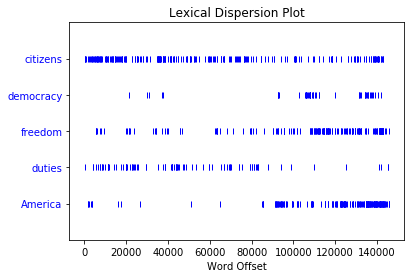

```python
text4.dispersion_plot(["citizens", "democracy", "freedom", "duties", "America"])
```

### 词汇计数

以文本中出现的词和标点符号为单位算出文本从头到尾的长度

```python
len(text3)
```

```
44764
```

```python
sorted(set(text3))
len(set(text3))
```

```
2789
```

```python
text3.count("smote")
```

```
5
```

对文本词汇丰富度进行测量

定义函数并且使用

```python
from __future__ import division
def lexical_diversity(text):
    return len(set(text)) / len(text)
lexical_diversity(text3)
```

```
0.06230453042623537
```

```python
def percentage(count, total):
    return 100 * count / total
percentage(text4.count('we'), len(text4))
```

```
0.7829279171098226
```

### 将文本当做词的列表

文本是词和标点符号的序列

```python
sent1
```

```
['Call', 'me', 'Ishmael', '.']
```

```python
len(sent1)
```

```
4
```

对列表使用Python加法运算

```python
sent4 + sent1
```

```
['Fellow',
 '-',
 'Citizens',
 'of',
 'the',
 'Senate',
 'and',
 'of',
 'the',
 'House',
 'of',
 'Representatives',
 ':',
 'Call',
 'me',
 'Ishmael',
 '.']
```

```python
['Monty', 'Python'] + ['and', 'the', 'Holy', 'Grail']
```

```
['Monty', 'Python', 'and', 'the', 'Holy', 'Grail']
```

```python
sent1.append("Some")
sent1
```

```
['Call', 'me', 'Ishmael', '.', 'Some']
```

通过在列表中出现的次序找出Python列表的元素

```python
text4[173]
```

```
'awaken'
```

```python
text4.index('awaken')
```

```
173
```

```python
sent = ['word1', 'word2', 'word3', 'word4', 'word5','word6', 'word7', 'word8', 'word9', 'word10']
sent[0]
```

```
'word1'
```

```python
sent[5:8]
```

```
['word6', 'word7', 'word8']
```

```python
sent[:3]
```

```
['word1', 'word2', 'word3']
```

```python
sent[5:]
```

```
['word6', 'word7', 'word8', 'word9', 'word10']
```

```python
sent[0] = 'First'
sent[9] = 'Last'
sent[1:9] = ['Second', 'Third']
sent
```

```
['First', 'Second', 'Third', 'Last']
```

### 变量

变量赋值的过程不产生任何输出

```python
my_sent = ['Bravely', 'bold', 'Sir', 'Robin', ',', 'rode','forth', 'from', 'Camelot', '.']
noun_phrase = my_sent[1:4]
noun_phrase
```

```
['bold', 'Sir', 'Robin']
```

```python
wOrDs = sorted(noun_phrase)
wOrDs
```

```
['Robin', 'Sir', 'bold']
```

### 字符串

字符串操作

```python
vocab = set(text1)
vocab_size = len(vocab)
vocab_size
```

```
19317
```

```python
name = 'Monty'
name[0]
```

```
'M'
```

```python
name * 2
```

```
'MontyMonty'
```

```python
' '.join(['Monty', 'Python'])
```

```
'Monty Python'
```

```python
'Monty Python'.split()
```

```
['Monty', 'Python']
```

```python
name + '!'
```

```
'Monty!'
```

## 语言计算：简单统计

### 频率分布

```python
fdist1 = FreqDist(text1)
print(fdist1)
```

```
<FreqDist with 19317 samples and 260819 outcomes>
```

```python
fdist1.most_common(100)
```

```
[(',', 18713),
 ('the', 13721),
 ('.', 6862),
 ('of', 6536),
 ('and', 6024),
 ('a', 4569),
 ('to', 4542),
 (';', 4072),
 ('in', 3916),
 ('that', 2982),
 ("'", 2684),
 ('-', 2552),
 ('his', 2459),
 ('it', 2209),
 ('I', 2124),
 ('s', 1739),
 ('is', 1695),
 ('he', 1661),
 ('with', 1659),
 ('was', 1632),
 ('as', 1620),
 ('"', 1478),
 ('all', 1462),
 ('for', 1414),
 ('this', 1280),
 ('!', 1269),
 ('at', 1231),
 ('by', 1137),
 ('but', 1113),
 ('not', 1103),
 ('--', 1070),
 ('him', 1058),
 ('from', 1052),
 ('be', 1030),
 ('on', 1005),
 ('so', 918),
 ('whale', 906),
 ('one', 889),
 ('you', 841),
 ('had', 767),
```

[output cut: 45 more lines]

```
 ('only', 360),
 ('such', 336),
 ('head', 335),
 ('though', 335),
 ('boat', 330),
 ('her', 329),
 ('time', 324),
 ('any', 320),
 ('who', 319),
 ('long', 318),
 ('very', 311),
 ('It', 310),
 ('than', 309),
 ('!"', 305),
 ('about', 304)]
```

```python
fdist1['white']
```

```
191
```

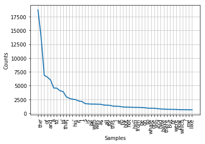

```python
fdist1.plot(50, cumulative=False)
```

查看只出现了一次的词

```python
list=fdist1.hapaxes()
len(list)
```

```
9002
```

### 细粒度地选择词语

寻找文本词汇表中长度超过15个字符的词

```python
V=set(text1)
long_words=[w for w in V if len(w)>15]
sorted(long_words)
```

```
['CIRCUMNAVIGATION',
 'Physiognomically',
 'apprehensiveness',
 'cannibalistically',
 'characteristically',
 'circumnavigating',
 'circumnavigation',
 'circumnavigations',
 'comprehensiveness',
 'hermaphroditical',
 'indiscriminately',
 'indispensableness',
 'irresistibleness',
 'physiognomically',
 'preternaturalness',
 'responsibilities',
 'simultaneousness',
 'subterraneousness',
 'supernaturalness',
 'superstitiousness',
 'uncomfortableness',
 'uncompromisedness',
 'undiscriminating',
 'uninterpenetratingly']
```

寻找频繁出现的长词

```python
fdist5=FreqDist(text5)
sorted(w for w in set(text5) if len(w)>7 and fdist5[w]>7)
```

```
['#14-19teens',
 '#talkcity_adults',
 '((((((((((',
 '........',
 'Question',
 'actually',
 'anything',
 'computer',
 'cute.-ass',
 'everyone',
 'football',
 'innocent',
 'listening',
 'remember',
 'seriously',
 'something',
 'together',
 'tomorrow',
 'watching']
```

## 词语搭配和二元模式

从文本中抽取词对列表，即二元模式(bigrams)

```python
text4.collocations()
```

```
United States; fellow citizens; four years; years ago; Federal
Government; General Government; American people; Vice President; Old
World; Almighty God; Fellow citizens; Chief Magistrate; Chief Justice;
God bless; every citizen; Indian tribes; public debt; one another;
foreign nations; political parties
```

```python
text8.collocations()
```

```
would like; medium build; social drinker; quiet nights; non smoker;
long term; age open; Would like; easy going; financially secure; fun
times; similar interests; Age open; weekends away; poss rship; well
presented; never married; single mum; permanent relationship; slim
build
```

```python
from nltk import bigrams
sorted(bigrams(['more', 'is', 'said', 'than', 'done']))
```

```
[('is', 'said'), ('more', 'is'), ('said', 'than'), ('than', 'done')]
```

## 其他计数

对长度进行统计

```python
[len(w) for w in text1]
```

```
[1,
 4,
 4,
 2,
 6,
 8,
 4,
 1,
 9,
 1,
 1,
 8,
 2,
 1,
 4,
 11,
 5,
 2,
 1,
 7,
 6,
 1,
 3,
 4,
 5,
 2,
 10,
 2,
 4,
 1,
 5,
 1,
 4,
 1,
 3,
 5,
 1,
 1,
 3,
 3,
```

[output cut: 946 more lines]

```
 2,
 5,
 4,
 4,
 5,
 1,
 5,
 1,
 4,
 5,
 5,
 4,
 1,
 2,
 ...]
```

```python
fdist = FreqDist(len(w) for w in text1)
print(fdist)
fdist
```

```
<FreqDist with 19 samples and 260819 outcomes>
```

```
FreqDist({1: 47933,
          2: 38513,
          3: 50223,
          4: 42345,
          5: 26597,
          6: 17111,
          7: 14399,
          8: 9966,
          9: 6428,
          10: 3528,
          11: 1873,
          12: 1053,
          13: 567,
          14: 177,
          15: 70,
          16: 22,
          17: 12,
          18: 1,
          20: 1})
```

```python
fdist.max()
```

```
3
```

```python
fdist.most_common()
```

```
[(3, 50223),
 (1, 47933),
 (4, 42345),
 (2, 38513),
 (5, 26597),
 (6, 17111),
 (7, 14399),
 (8, 9966),
 (9, 6428),
 (10, 3528),
 (11, 1873),
 (12, 1053),
 (13, 567),
 (14, 177),
 (15, 70),
 (16, 22),
 (17, 12),
 (18, 1),
 (20, 1)]
```

```python
fdist = FreqDist(len(w) for w in text1)
print(fdist)
```

```
<FreqDist with 19 samples and 260819 outcomes>
```

```python
fdist[3]
```

```
50223
```

```python
fdist.freq(3)
```

```
0.19255882431878046
```

## 回到Python：决策与控制

### 条件

使用数字比较运算符，例如 <,<=,==,|=,>和>=，从一个句子中选择不同的词

```python
sent7
```

```
['Pierre',
 'Vinken',
 ',',
 '61',
 'years',
 'old',
 ',',
 'will',
 'join',
 'the',
 'board',
 'as',
 'a',
 'nonexecutive',
 'director',
 'Nov.',
 '29',
 '.']
```

```python
[w for w in sent7 if len(w) <= 4]
```

```
[',', '61', 'old', ',', 'will', 'join', 'the', 'as', 'a', 'Nov.', '29', '.']
```

```python
[w for w in sent7 if len(w) < 4]
```

```
[',', '61', 'old', ',', 'the', 'as', 'a', '29', '.']
```

```python
[w for w in sent7 if len(w) == 4]
```

```
['will', 'join', 'Nov.']
```

```python
[w for w in sent7 if len(w) != 4]
```

```
['Pierre',
 'Vinken',
 ',',
 '61',
 'years',
 'old',
 ',',
 'the',
 'board',
 'as',
 'a',
 'nonexecutive',
 'director',
 '29',
 '.']
```

### 词汇函数

例如s.startswith(t), s.endswith(t), t in s, s.islower(), s.isupper(), s.isalpha(), s.isalnum(), s.isdigit(), s.istitle()

```python
sorted(w for w in set(text1) if w.endswith('ableness'))
```

```
['comfortableness',
 'honourableness',
 'immutableness',
 'indispensableness',
 'indomitableness',
 'intolerableness',
 'palpableness',
 'reasonableness',
 'uncomfortableness']
```

```python
sorted(term for term in set(text4) if 'gnt' in term)
```

```
['Sovereignty', 'sovereignties', 'sovereignty']
```

```python
sorted(item for item in set(sent7) if item.isdigit())
```

```
['29', '61']
```

```python
sorted(item for item in set(text6) if item.istitle())
```

```
['A',
 'Aaaaaaaaah',
 'Aaaaaaaah',
 'Aaaaaah',
 'Aaaah',
 'Aaaaugh',
 'Aaagh',
 'Aaah',
 'Aaauggh',
 'Aaaugh',
 'Aaauugh',
 'Aagh',
 'Aah',
 'Aauuggghhh',
 'Aauuugh',
 'Aauuuuugh',
 'Aauuuves',
 'Action',
 'Actually',
 'African',
 'Ages',
 'Aggh',
 'Agh',
 'Ah',
 'Ahh',
 'Alice',
 'All',
 'Allo',
 'Almighty',
 'Alright',
 'Am',
 'Amen',
 'An',
 'Anarcho',
 'And',
 'Angnor',
 'Anthrax',
 'Antioch',
 'Anybody',
 'Anyway',
```

[output cut: 416 more lines]

```
 'With',
 'Woa',
 'Wood',
 'Would',
 'Y',
 'Yapping',
 'Yay',
 'Yeaaah',
 'Yeaah',
 'Yeah',
 'Yes',
 'You',
 'Your',
 'Yup',
 'Zoot']
```

```python
sorted(w for w in set(text7) if '-' in w and 'index' in w)
```

```
['Stock-index',
 'index-arbitrage',
 'index-fund',
 'index-options',
 'index-related',
 'stock-index']
```

```python
sorted(wd for wd in set(text3) if wd.istitle() and len(wd) > 10)
```

```
['Abelmizraim',
 'Allonbachuth',
 'Beerlahairoi',
 'Canaanitish',
 'Chedorlaomer',
 'Girgashites',
 'Hazarmaveth',
 'Hazezontamar',
 'Ishmeelites',
 'Jegarsahadutha',
 'Jehovahjireh',
 'Kirjatharba',
 'Melchizedek',
 'Mesopotamia',
 'Peradventure',
 'Philistines',
 'Zaphnathpaaneah']
```

```python
sorted(w for w in set(sent7) if not w.islower())
```

```
[',', '.', '29', '61', 'Nov.', 'Pierre', 'Vinken']
```

### 对每个元素进行操作

```python
[len(w) for w in text1]
```

```
[1,
 4,
 4,
 2,
 6,
 8,
 4,
 1,
 9,
 1,
 1,
 8,
 2,
 1,
 4,
 11,
 5,
 2,
 1,
 7,
 6,
 1,
 3,
 4,
 5,
 2,
 10,
 2,
 4,
 1,
 5,
 1,
 4,
 1,
 3,
 5,
 1,
 1,
 3,
 3,
```

[output cut: 946 more lines]

```
 2,
 5,
 4,
 4,
 5,
 1,
 5,
 1,
 4,
 5,
 5,
 4,
 1,
 2,
 ...]
```

```python
[w.upper() for w in text1]
```

```
['[',
 'MOBY',
 'DICK',
 'BY',
 'HERMAN',
 'MELVILLE',
 '1851',
 ']',
 'ETYMOLOGY',
 '.',
 '(',
 'SUPPLIED',
 'BY',
 'A',
 'LATE',
 'CONSUMPTIVE',
 'USHER',
 'TO',
 'A',
 'GRAMMAR',
 'SCHOOL',
 ')',
 'THE',
 'PALE',
 'USHER',
 '--',
 'THREADBARE',
 'IN',
 'COAT',
 ',',
 'HEART',
 ',',
 'BODY',
 ',',
 'AND',
 'BRAIN',
 ';',
 'I',
 'SEE',
 'HIM',
```

[output cut: 946 more lines]

```
 'OF',
 'WHICH',
 'SOME',
 'WERE',
 'FORTY',
 '-',
 'EIGHT',
 ',',
 'SOME',
 'FIFTY',
 'YARDS',
 'LONG',
 '.',
 'HE',
 ...]
```

```python
len(text1)
```

```
260819
```

```python
len(set(text1))
```

```
19317
```

```python
len(set([word.lower() for word in text1]))
```

```
17231
```

```python
len(set([word.lower() for word in text1 if word.isalpha()]))
```

```
16948
```

```python
sorted(t for t in set(text2) if 'cie' in t or 'cei' in t)
```

```
['ancient',
 'ceiling',
 'conceit',
 'conceited',
 'conceive',
 'conscience',
 'conscientious',
 'conscientiously',
 'deceitful',
 'deceive',
 'deceived',
 'deceiving',
 'deficiencies',
 'deficiency',
 'deficient',
 'delicacies',
 'excellencies',
 'fancied',
 'insufficiency',
 'insufficient',
 'legacies',
 'perceive',
 'perceived',
 'perceiving',
 'prescience',
 'prophecies',
 'receipt',
 'receive',
 'received',
 'receiving',
 'society',
 'species',
 'sufficient',
 'sufficiently',
 'undeceive',
 'undeceiving']
```

## 嵌套代码块

```python
word = 'cat'
if len(word) < 5:
    print('word length is less than 5')
```

```
word length is less than 5
```

```python
if len(word) >= 5:
    print('word length is greater than or equal to 5')
```

### 条件循环

结合if语句和for语句

```python
sent1 = ['Call', 'me', 'Ishmael', '.']
for xyzzy in sent1:
    if xyzzy.endswith('l'):
        print(xyzzy)
```

```
Call
Ishmael
```

```python
for word in ['Call', 'me', 'Ishmael', '.']:
    print(word)
```

```
Call
me
Ishmael
.
```

```python
for token in sent1:
    if token.islower():
        print(token, 'is a lowercase word')
    elif token.istitle():
        print(token, 'is a titlecase word')
    else:
        print(token, 'is punctuation')
```

```
Call is a titlecase word
me is a lowercase word
Ishmael is a titlecase word
. is punctuation
```

创建一个包含cie或者cei的词的链表，再循环输出其中的每一项

```python
tricky = sorted(w for w in set(text2) if 'cie' in w or 'cei' in w)
for word in tricky:
    print(word, end=' ')
```

[output not shown]